# PROSPER LOAN DATA

### Distribution Of Stated Monthly Income Per Month

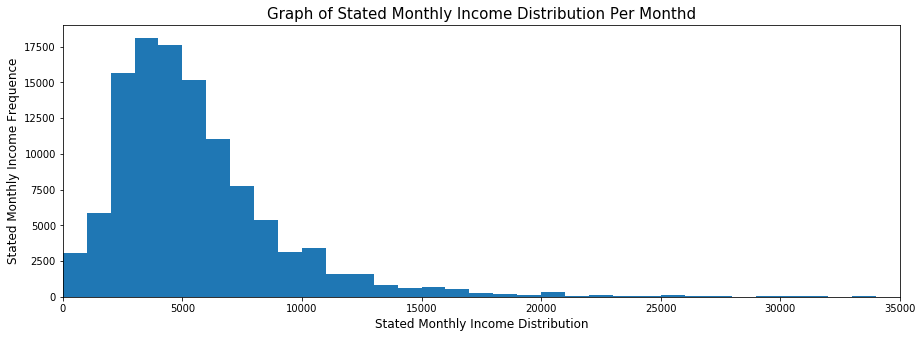

```python
plt.figure(figsize=[15, 5])
bins = np.arange(prosper_loan_copy['statedmonthlyincome'].min(), prosper_loan_copy['statedmonthlyincome'].max()+1000, 1000)
plt.hist(data = prosper_loan_copy, x = 'statedmonthlyincome', bins=bins)
plt.xlim(0, 35000)
plt.title('Graph of Stated Monthly Income Distribution Per Monthd', fontsize=15)
plt.ylabel('Stated Monthly Income Frequence', fontsize=12)
plt.xlabel('Stated Monthly Income Distribution', fontsize=12);
```

#### OBSERVATION

- From the observation the stated monthly income has a large range of outliers in which the graph requied a lower bound and a upper bound to view the main histogram plot from `0 to 35000`
- From the observation the this histograme requires a log transformation to make the stated monthly income evenlly distributed

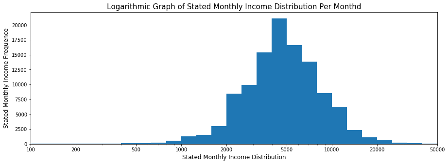

```python
plt.figure(figsize=[15, 5])
bins = 10**np.arange(0.0, 6.24+0.1, 0.1)
plt.hist(data = prosper_loan_copy, x = 'statedmonthlyincome', bins=bins)
plt.xscale('log')
xticks = [100, 200, 500, 1000, 2000, 5000, 10000, 20000, 50000]
xticks_str = ['{}'.format(x) for x in xticks]
plt.xticks(xticks, xticks_str)
plt.title('Logarithmic Graph of Stated Monthly Income Distribution Per Monthd', fontsize=15)
plt.ylabel('Stated Monthly Income Frequence', fontsize=12)
plt.xlabel('Stated Monthly Income Distribution', fontsize=12)
plt.xlim(100, 50000);
```

#### OBSERVATION

- From our observation of log transform the stated monthly income is now evenly distributed which now has a symmetric shape

### Distribution Of Monthly Loan Payment

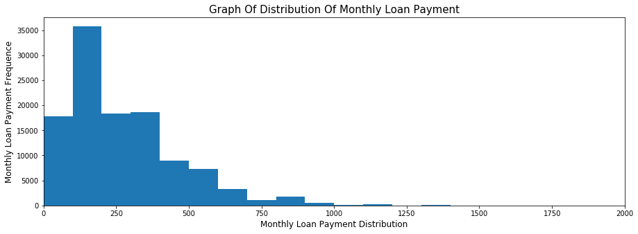

```python
plt.figure(figsize=[15, 5])
bins = np.arange(prosper_loan_copy['monthlyloanpayment'].min(), prosper_loan_copy['monthlyloanpayment'].max()+100, 100)
plt.hist(data = prosper_loan_copy, x = 'monthlyloanpayment', bins=bins)
plt.title('Graph Of Distribution Of Monthly Loan Payment', fontsize=15)
plt.ylabel('Monthly Loan Payment Frequence', fontsize=12)
plt.xlabel('Monthly Loan Payment Distribution', fontsize=12)
plt.xlim(0, 2000);
```

#### OBSERVATION

- From the observation the monthly loan payment has a large range of outliers in which the graph requied a lower bound and a upper bound to view the main histogram plot from `0 to 2000`
- From the observation the this histograme requires a log transformation to make the stated monthly income evenly distributed

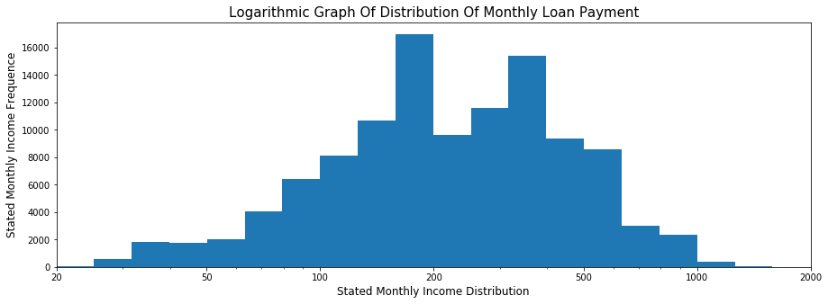

```python
plt.figure(figsize=[15, 5])
bins = 10**np.arange(0.0, 3.35+0.1, 0.1)
plt.hist(data = prosper_loan_copy, x = 'monthlyloanpayment', bins=bins)
plt.xscale('log')
xticks = [10, 20, 50, 100, 200, 500, 1000, 2000, 5000]
xticks_str = ['{}'.format(x) for x in xticks]
plt.xticks(xticks, xticks_str)
plt.title('Logarithmic Graph Of Distribution Of Monthly Loan Payment', fontsize=15)
plt.ylabel('Stated Monthly Income Frequence', fontsize=12)
plt.xlabel('Stated Monthly Income Distribution', fontsize=12)
plt.xlim(20, 2000);
```

#### OBSERVATION

- From our observation of log transform the monthly loan payment is now evenly distributed which now has a Bimodel shape